# Marketing campaign analysis

Carolyn Ford

2022-06-25

### Introduction

We recently conducted an email marketing campaign aimed at our base of 64,000 customers with the purpose of increasing visits and spend. In the past 12 months we have earned $15493481.97 from this customer base. Having sent a marketing email to 2/3 of our customers, we yielded $67258.13 of additional revenue. The dataset is provided by Kevin Hillstrom, [Mine that data e-mail analytics data mining challenge, 2008 03 20](https://blog.minethatdata.com/2008/03/minethatdata-e-mail-analytics-and-data.html)

The customer database includes the following fields:

- **Recency** - time elapsed since last purchase, months
- **History segment** - one of seven categories from low spend to high
- **History** - value of the spend, continuous
- **Mens** - a binary variable, whether purchases from mens product line occurred
- **Womens** - a binary variable, whether purchases from womens product line occurred
- **Zip code** - location description of customers, segmented into Rural, Suburban or Urban
- **Newbie** - reflecting whether the customer is a new one, or previous
- **Channel** - multi-channel, phone or web
- **Segment** - the marketing treatment received: either no email (control), men’s focused email (treatment) or women’s focused email (treatment)
- **Visit** - a binary variable reflecting whether a visit to one of the channels occurred after the marketing campaign
- **Conversion** - a binary variable reflecting whether spend occurred after the visit
- **Spend** - the value of the spend, if it occurred

Our goal in this report is to understand our customer base from Recency-Monetary Value and campaign lift perspectives. Finally, we will offer a recommendation as to which customers to cull from our database in an effort to reduce marketing costs while maintaining or enhancing revenue.

### Our customer base

Looking at recency of purchases first, we can see that a plurality of customers have purchased recently (within the last two months), or more distantly (beyond nine months).

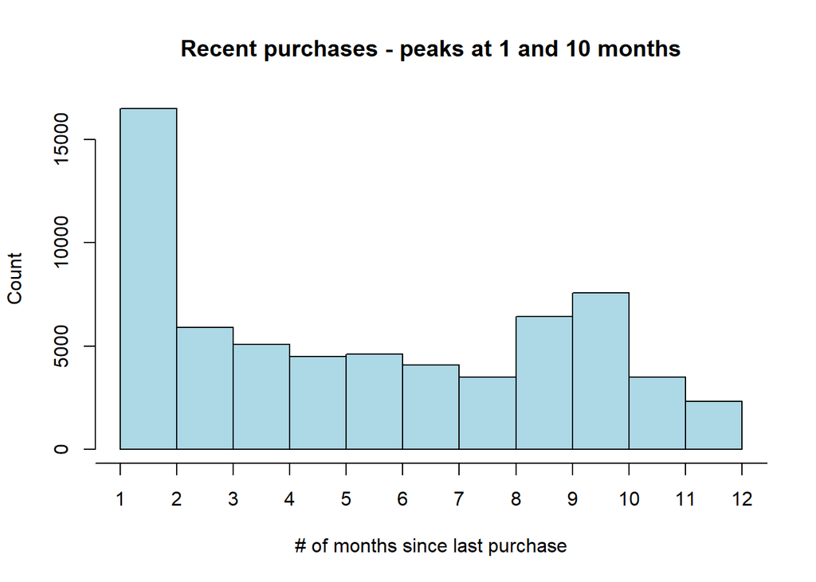

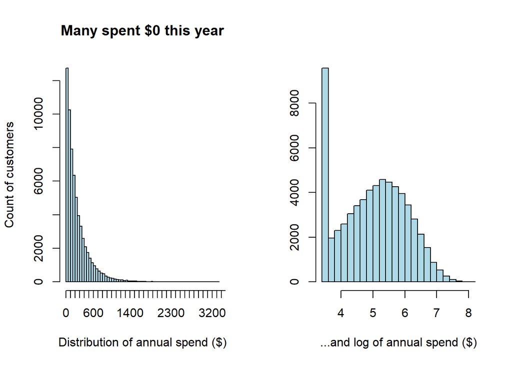

By looking at location and spend by channel, we see the importance of operating multi-channel versus solely by phone or by web.

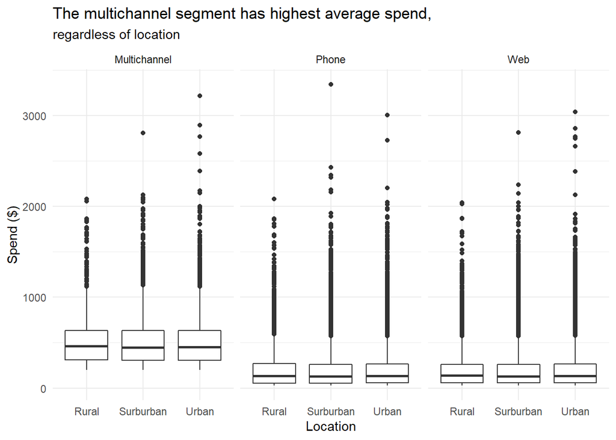

### Recency-Monetary Value Analysis

We used RM analysis to create more nuanced customer segments.

With Recency, we grouped by quintiles:

- R5 - (1,2] months since last purchase
- R4 - (2,4]
- R3 - (4,7]
- R2 - (7,10]
- R1 - (10,12]

With Monetary Value, we also grouped by quintiles:

- M5 - ($382, $3345.93]
- M4 - ($211, $382]
- M3 - ($115, $211]
- M2 - ($50.30, $115]
- M1 - ($29.99, $50.30]

As such, an RM segment of 55 refers to the count of customers who have made purchases within the last two months, and the monetary value of their purchases this past year total $382 or more. An RM segment of 11, in contrast, refers to the count of customers who made their most recent purchases 11 to 12 months ago, with value of $50.30 or less.

In the tables below we can see that our ‘best’ segment, RM 55 as the recent, high spenders provided the highest number of visits post campaign, as well as the highest spend. To be sure, we cannot live on a “diet” of RM 55s, so attracting customers from other RM segments to visit and spend at the store is important too:

| RM/visit | x0 | x1 | Total |
| --- | --- | --- | --- |
| 11 | 89% (1392) | 11% (167) | 100% (1559) |
| 12 | 89% (1269) | 11% (163) | 100% (1432) |
| 13 | 89% (1151) | 11% (148) | 100% (1299) |
| 14 | 85% (862) | 15% (147) | 100% (1009) |
| 15 | 82% (443) | 18% (94) | 100% (537) |
| 21 | 90% (3863) | 10% (438) | 100% (4301) |
| 22 | 89% (3615) | 11% (447) | 100% (4062) |
| 23 | 90% (3384) | 10% (360) | 100% (3744) |
| 24 | 86% (2833) | 14% (474) | 100% (3307) |
| 25 | 85% (1773) | 15% (314) | 100% (2087) |
| 31 | 88% (2449) | 12% (329) | 100% (2778) |
| 32 | 88% (2400) | 12% (319) | 100% (2719) |
| 33 | 87% (2372) | 13% (364) | 100% (2736) |
| 34 | 84% (2207) | 16% (426) | 100% (2633) |
| 35 | 83% (1929) | 17% (398) | 100% (2327) |
| 41 | 86% (1641) | 14% (257) | 100% (1898) |
| 42 | 86% (1761) | 14% (287) | 100% (2048) |
| 43 | 86% (1851) | 14% (297) | 100% (2148) |
| 44 | 82% (1909) | 18% (426) | 100% (2335) |
| 45 | 82% (2081) | 18% (471) | 100% (2552) |
| 51 | 84% (1899) | 16% (365) | 100% (2264) |
| 52 | 84% (2140) | 16% (400) | 100% (2540) |
| 53 | 82% (2370) | 18% (503) | 100% (2873) |
| 54 | 80% (2821) | 20% (694) | 100% (3515) |
| 55 | 79% (4191) | 21% (1106) | 100% (5297) |
| Total | 85% (54606) | 15% (9394) | 100% (64000) |

Top 10 RM segments

| RM segment | # of customers | Post campaign spend |
| --- | --- | --- |
| 55 | 5297 | $9,817.45 |
| 54 | 3515 | $4,740.64 |
| 21 | 4301 | $4,657.28 |
| 52 | 2540 | $4,073.77 |
| 24 | 3307 | $3,860.90 |
| 45 | 2552 | $3,640.21 |
| 44 | 2335 | $3,493.30 |
| 23 | 3744 | $3,041.95 |
| 35 | 2327 | $2,985.58 |
| 25 | 2087 | $2,647.58 |

### Our email campaign

To boost spend, we divided our customer base into three roughly equal segments and selected a treatment at random (Men’s E-Mail, No E-Mail, Women’s E-Mail).

First we look at the proportions that yielded visits, by treatment. We can see the Men’s E-Mail yielded the highest proportion of visits to the store.

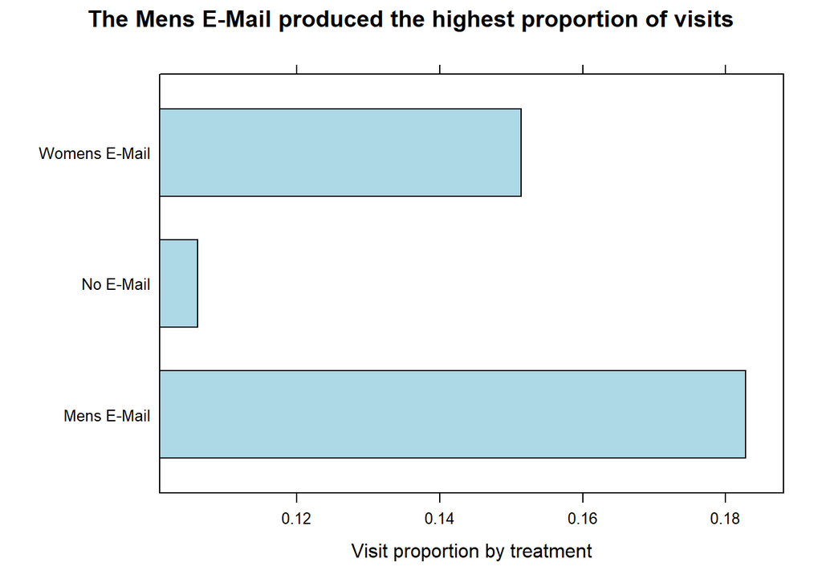

Similarly, the Men’s E-Mail yielded the highest conversion from the visit to spend stages:

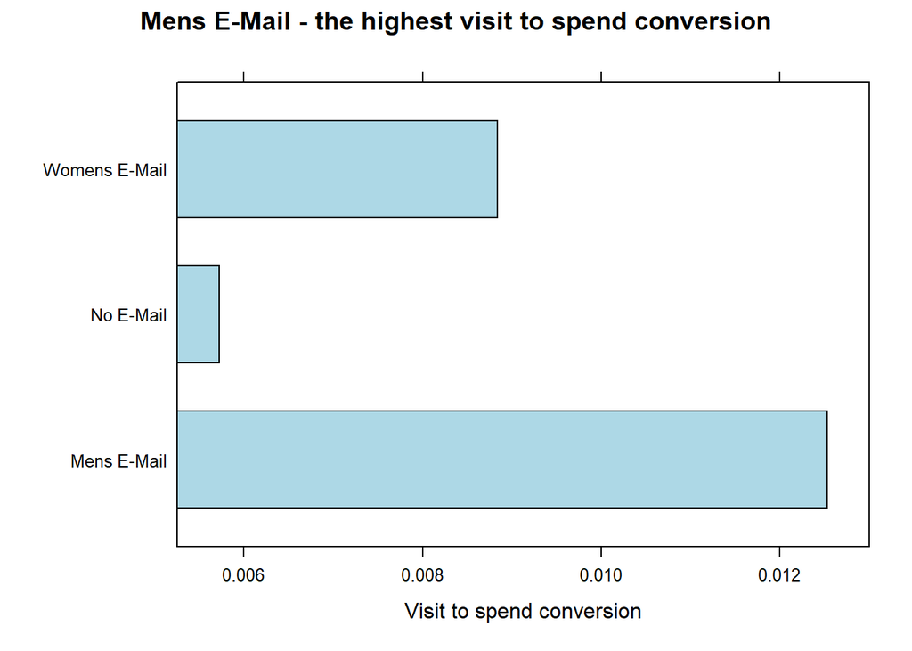

Next, we look at sum of post campaign spend by treatment. By now, it is not surprising to see that the Men’s E-Mail resulted in the highest revenue following the campaign:

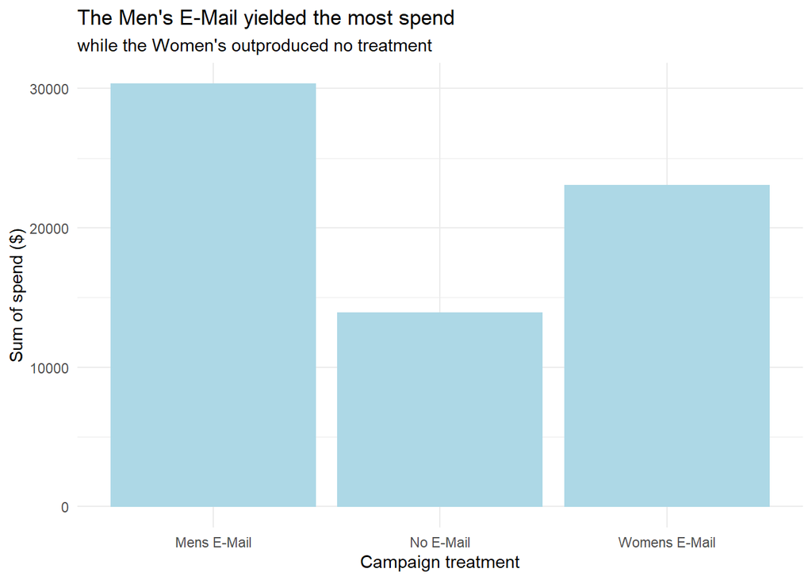

### Key Question

If we had to eliminate 10,000 customers from receiving an e-mail campaign, which customers would we suppress from the campaign?

There are 10001 customers whose customer value over the past 12 months is less than $44.01 and who did not visit the store post campaign. As a result, if sending emails costs us money, then we should remove the 10,001 from the list, as they have the lowest probability of reaching the visit stage.

Of note there are also 8816 customers who visited the store post campaign, but who did not convert to a spend. Although out of the scope of our analysis here, it does cost us money to provide service to those customers.

## Conclusion

We have explored our customer base by the Recency-Monetary Value method as well as by campaign treatments and lift to store visits and spend.